# Carotenoids and immune data

# Log transformed immune cells

## resid normality checks

I need to figure out how to make a function that extracts makes a QQplot for each model. But since IL-5 was significant, let’s look at how the residuals look for this cytokine (for every comparison) before log transforming

```r
#qqplot_fx <- function(cytokine){
  #qqnorm(resid(cyto_seq_models$cytokine))
  #qqline(resid(cyto_seq_models$cytokine))
#}

#qqplot_fx("il_5")

#cyto_seq_results$
```

### seq

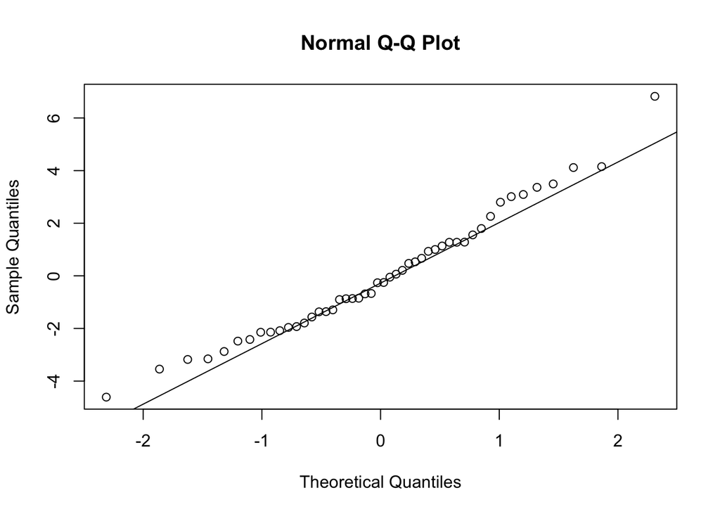

```r
qqnorm(resid(cells_seq_models$x25_cd19_cd3_b_cells))
qqline(resid(cells_seq_models$x25_cd19_cd3_b_cells))
```

Doesn’t look bad

### intervention

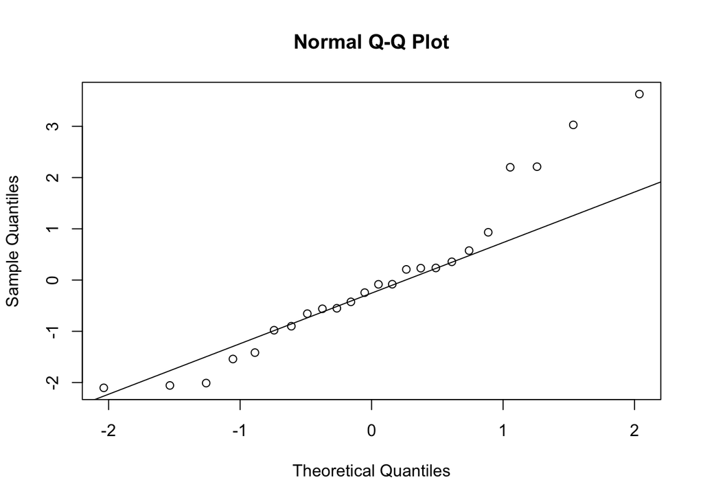

```r
qqnorm(resid(cells_trt_models$x25_cd19_cd3_b_cells))
qqline(resid(cells_trt_models$x25_cd19_cd3_b_cells))
```

### red

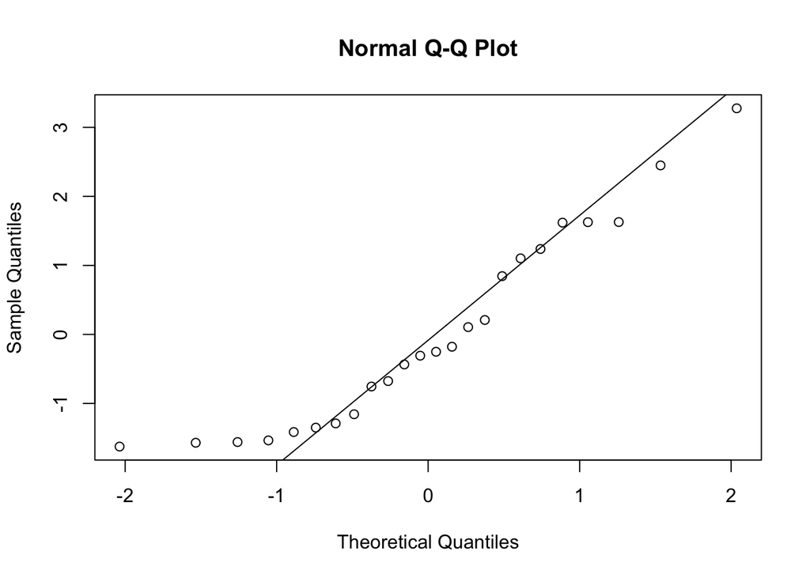

```r
qqnorm(resid(cells_trtR_models$x25_cd19_cd3_b_cells))
qqline(resid(cells_trtR_models$x25_cd19_cd3_b_cells))
```

### yellow

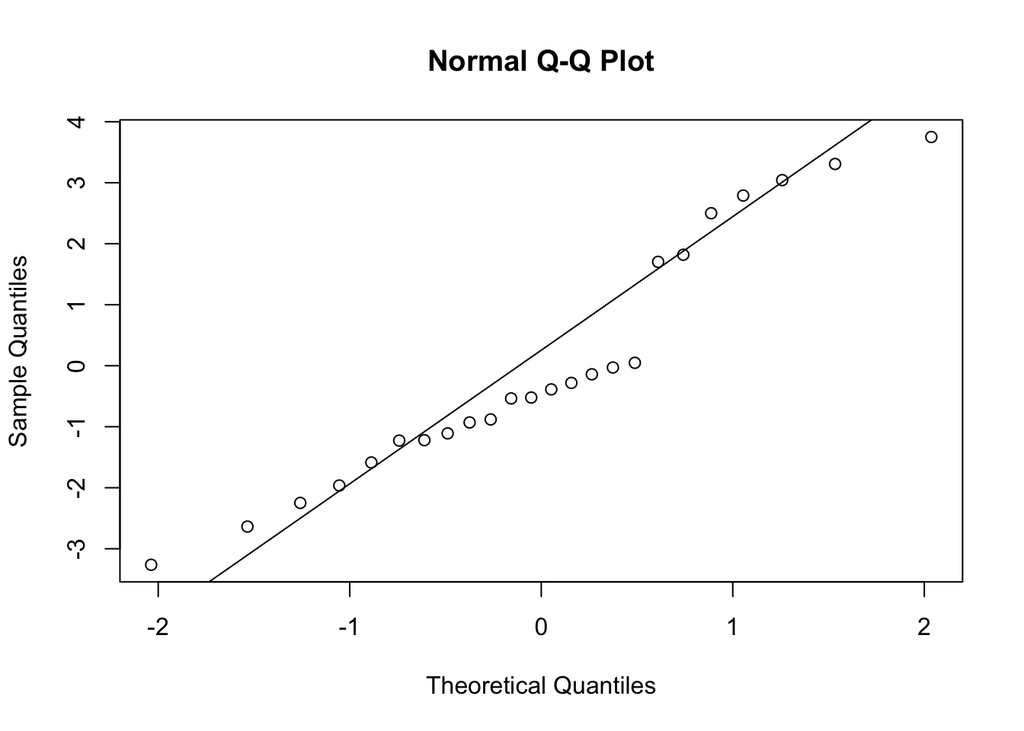

```r
qqnorm(resid(cells_trtY_models$x25_cd19_cd3_b_cells))
qqline(resid(cells_trtY_models$x25_cd19_cd3_b_cells))
```

Wrangle

```r
cells_log2_long <- cells_long %>%
  mutate(log2_cell_value = log2(cell_value)) %>%
  filter(log2_cell_value != -Inf) # remove 0s
```

## Sequence effect test

```r
# lmer model function
cells_log2_seq_function <- function(cells_log2_long) {
  lmer(log2_cell_value ~ sequence + (1|patient_id), data = cells_log2_long, REML = TRUE)
}

# break data up into subsets based on cytokine, then apply funtion to each subset
cells_log2_seq_models <- map(split(cells_log2_long,
                              cells_log2_long$cell_type),
                   cells_log2_seq_function)

# create single data frame of results. apply tidy from broom.mixed package to clean up results
cells_log2_seq_results <- map_df(cells_log2_seq_models,
                            tidy,
                            .id = "cell_type")

cells_log2_seq_results_coef <- cells_log2_seq_results %>%
  filter(effect == "fixed") %>%
  filter(term != "(Intercept)") %>%
  add_significance(p.col = "p.value",
                   output.col = "p.sig",
                   cutpoints = c(0, 1e-04, 0.001, 0.01, 0.05, 1),
                   symbols = c("****", "***", "**", "*", "ns")
                   )
```

### Results

```r
kable(cells_log2_seq_results_coef, format = "markdown", digits = 3)
```

| cell_type | effect | group | term | estimate | std.error | statistic | df | p.value | p.sig |
| --- | --- | --- | --- | --- | --- | --- | --- | --- | --- |
| x01_cd45_cd66b_lymph_dc_mono | fixed | NA | sequenceY_R | 0.002 | 0.035 | 0.064 | 10.000 | 0.950 | ns |
| x02_cd45_cd66b_grans | fixed | NA | sequenceY_R | 0.084 | 0.876 | 0.096 | 10.000 | 0.926 | ns |
| x03_cd3_cd45_cd3_t_cells | fixed | NA | sequenceY_R | 0.226 | 0.317 | 0.712 | 10.000 | 0.492 | ns |
| x04_tc_rgd_cd3_ab_t_cells | fixed | NA | sequenceY_R | 0.213 | 0.340 | 0.625 | 10.000 | 0.546 | ns |
| x05_cd4_cd8_cd8_t_cells | fixed | NA | sequenceY_R | 0.573 | 0.367 | 1.562 | 10.000 | 0.149 | ns |
| x06_cd45ro_cd45ra_naive_cd8 | fixed | NA | sequenceY_R | 0.658 | 0.858 | 0.767 | 10.000 | 0.461 | ns |
| x07_cd46ro_cd45ra_cm_cd8 | fixed | NA | sequenceY_R | 0.500 | 0.516 | 0.969 | 10.000 | 0.355 | ns |
| x08_cd45ro_cd45ra_em_cd8 | fixed | NA | sequenceY_R | 0.891 | 0.711 | 1.254 | 10.000 | 0.239 | ns |
| x09_cd45r0_cd45ra_te_cd8 | fixed | NA | sequenceY_R | -0.186 | 0.431 | -0.432 | 10.000 | 0.675 | ns |
| x10_cd38_hladr_activated_cd8 | fixed | NA | sequenceY_R | 0.068 | 0.398 | 0.172 | 10.000 | 0.867 | ns |
| x11_cd4_cd8_cd4_t_cells | fixed | NA | sequenceY_R | 0.116 | 0.507 | 0.230 | 10.000 | 0.823 | ns |
| x12_cd45ro_cd45ra_naive_cd4 | fixed | NA | sequenceY_R | 0.489 | 0.725 | 0.675 | 10.000 | 0.515 | ns |
| x13_cd45ro_cd45ra_cm_cd4 | fixed | NA | sequenceY_R | 0.055 | 0.515 | 0.108 | 10.000 | 0.916 | ns |
| x14_cd45ro_cd45ra | fixed | NA | sequenceY_R | 0.383 | 0.379 | 1.013 | 10.000 | 0.335 | ns |
| x15_cd45ro_cd45ra_te_cd4 | fixed | NA | sequenceY_R | 0.964 | 0.886 | 1.088 | 10.000 | 0.302 | ns |
| x16_cd38_hladr_activated_cd4 | fixed | NA | sequenceY_R | 0.141 | 0.408 | 0.345 | 10.000 | 0.737 | ns |
| x17_cd25_cd127_tregs | fixed | NA | sequenceY_R | 0.334 | 0.449 | 0.745 | 10.000 | 0.473 | ns |
| x18_ccr4_cd4_total_ccr4_treg | fixed | NA | sequenceY_R | 0.495 | 0.448 | 1.105 | 10.001 | 0.295 | ns |
| x19_cd45ra_cd45ro_ccr4_treg_naive | fixed | NA | sequenceY_R | 0.727 | 0.688 | 1.056 | 10.000 | 0.316 | ns |
| x20_hladr_total_ccr4_treg_activated | fixed | NA | sequenceY_R | 0.198 | 0.364 | 0.545 | 10.000 | 0.598 | ns |
| x21_cd45ra_cd45ro_ccr4_treg_memory | fixed | NA | sequenceY_R | 0.422 | 0.442 | 0.956 | 10.000 | 0.362 | ns |
| x22_cxcr3_ccr6_th1 | fixed | NA | sequenceY_R | 1.429 | 1.201 | 1.190 | 10.000 | 0.262 | ns |
| x23_cxcr3_ccr6_th2 | fixed | NA | sequenceY_R | 1.660 | 1.442 | 1.151 | 10.000 | 0.276 | ns |
| x24_cxcr3_ccr6_th17 | fixed | NA | sequenceY_R | 1.479 | 1.223 | 1.209 | 10.000 | 0.254 | ns |
| x25_cd19_cd3_b_cells | fixed | NA | sequenceY_R | -0.074 | 0.456 | -0.162 | 10.000 | 0.874 | ns |
| x26_cd27_ig_d_naive_b_cells | fixed | NA | sequenceY_R | 0.012 | 0.502 | 0.023 | 10.000 | 0.982 | ns |
| x27_cd27_ig_d_memory_b_cells | fixed | NA | sequenceY_R | -0.461 | 0.551 | -0.837 | 10.000 | 0.422 | ns |
| x28_cd27_ig_d_memory_resting_b_cells | fixed | NA | sequenceY_R | -0.400 | 0.709 | -0.564 | 10.000 | 0.585 | ns |
| x30_cd27_cd38_plasmablasts | fixed | NA | sequenceY_R | -0.795 | 0.652 | -1.220 | 9.743 | 0.251 | ns |
| x31_cd14_monocytes | fixed | NA | sequenceY_R | -0.405 | 0.448 | -0.905 | 10.000 | 0.387 | ns |
| x32_cd16_non_classical_mono | fixed | NA | sequenceY_R | -0.531 | 0.672 | -0.790 | 10.000 | 0.448 | ns |
| x33_cd16_classical_mono | fixed | NA | sequenceY_R | -0.353 | 0.447 | -0.789 | 10.000 | 0.449 | ns |
| x34_hladr_cd56 | fixed | NA | sequenceY_R | -0.354 | 0.442 | -0.800 | 10.000 | 0.442 | ns |
| x35_cd16_cd123_cd11c_p_dc | fixed | NA | sequenceY_R | -0.757 | 0.625 | -1.211 | 10.000 | 0.254 | ns |
| x36_cd16_cd123_cd11c_m_dc | fixed | NA | sequenceY_R | -0.278 | 0.457 | -0.608 | 10.000 | 0.557 | ns |
| x37_cd56_cd161_cd123_nk_cells | fixed | NA | sequenceY_R | -0.362 | 0.644 | -0.562 | 10.000 | 0.587 | ns |
| x38_cd16_nk_cells | fixed | NA | sequenceY_R | 0.213 | 0.631 | 0.338 | 10.000 | 0.742 | ns |
| x40_cd14_mdsc_mono | fixed | NA | sequenceY_R | -0.711 | 0.789 | -0.901 | 46.000 | 0.372 | ns |
| x41_cd66b_mdsc_grans | fixed | NA | sequenceY_R | -0.441 | 1.071 | -0.412 | 10.000 | 0.689 | ns |

```r
# extract statistically significant cytokines
cells_log2_seq_psig <- cells_log2_seq_results_coef %>%
  filter(cells_log2_seq_results_coef$p.value < 0.05)

print(cells_log2_seq_psig$cell_type)
```

```
## character(0)
```

*No sequence effects

### Resid check

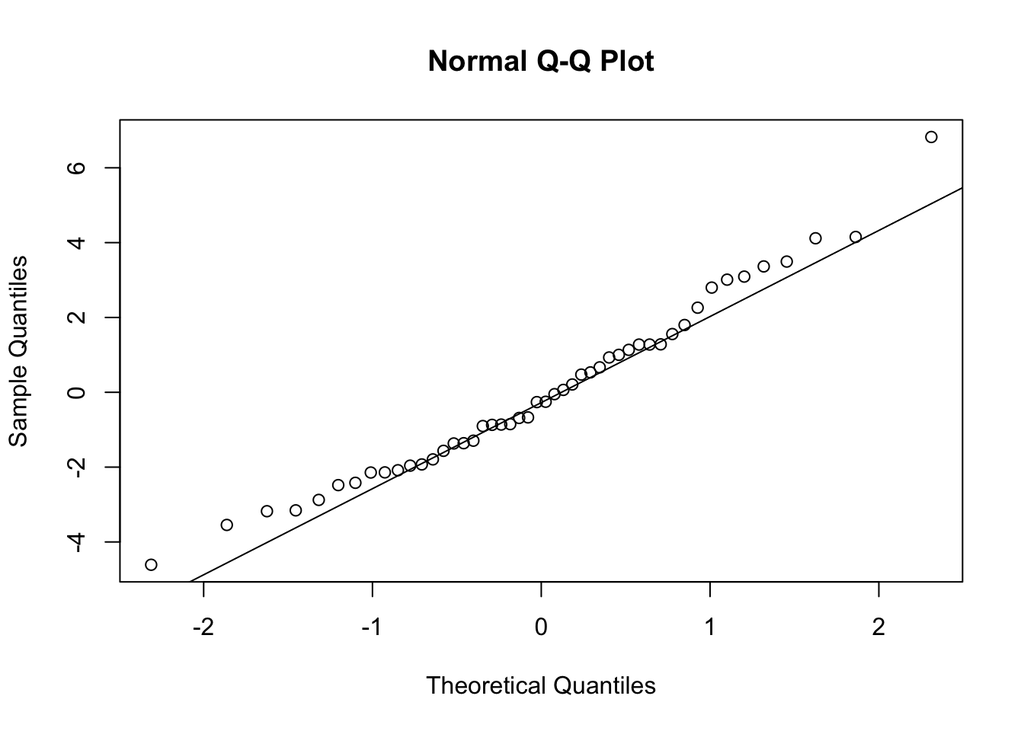

```r
# before log transform
qqnorm(resid(cells_seq_models$x25_cd19_cd3_b_cells))
qqline(resid(cells_seq_models$x25_cd19_cd3_b_cells))
```

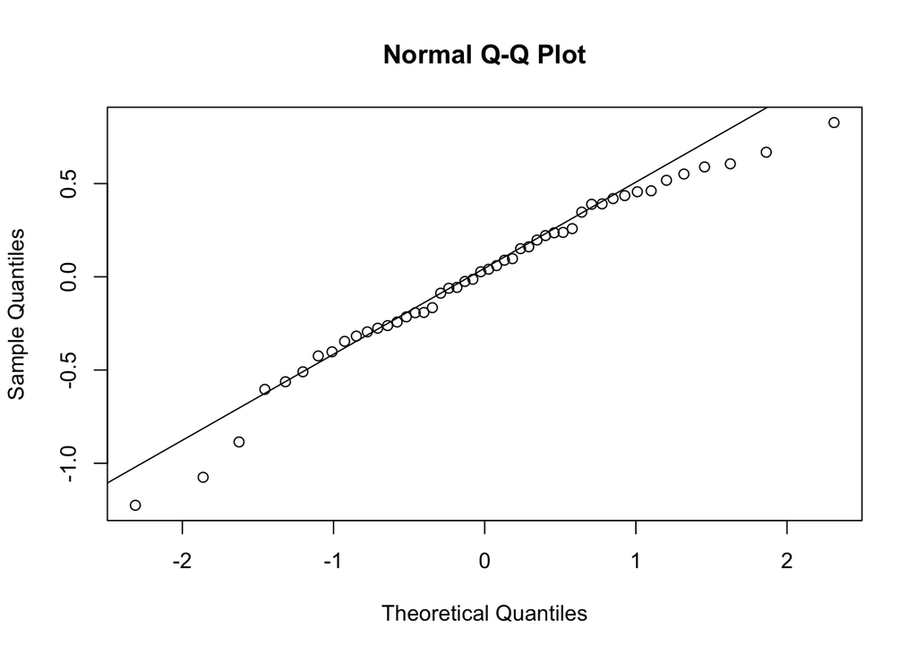

```r
# after log transform
qqnorm(resid(cells_log2_seq_models$x25_cd19_cd3_b_cells))
qqline(resid(cells_log2_seq_models$x25_cd19_cd3_b_cells))
```

## Yellow treatment

```r
# subset data into yellow results
cells_log2_Y_long <- cells_log2_long %>%
  filter(intervention == "Yellow")
```

```r
# lmer model function
cells_log2_Y_function <- function(cells_log2_Y_long) {
  lmer(log2_cell_value ~ sequence + (1|patient_id), data = cells_log2_Y_long, REML = TRUE)
}

# break data up into subsets based on cytokine, then apply funtion to each subset
cells_log2_Y_models <- map(split(cells_log2_Y_long,
                              cells_log2_Y_long$cell_type),
                   cells_log2_Y_function)

# create single data frame of results. apply tidy from broom.mixed package to clean up results
cells_log2_Y_results <- map_df(cells_log2_Y_models,
                            tidy,
                            .id = "cell_type")

cells_log2_Y_results_coef <- cells_log2_Y_results %>%
  filter(effect == "fixed") %>%
  filter(term != "(Intercept)") %>%
  add_significance(p.col = "p.value",
                   output.col = "p.sig",
                   cutpoints = c(0, 1e-04, 0.001, 0.01, 0.05, 1),
                   symbols = c("****", "***", "**", "*", "ns")
                   )
```

### Results

```r
kable(cells_log2_Y_results_coef, format = "markdown", digits = 3)
```

| cell_type | effect | group | term | estimate | std.error | statistic | df | p.value | p.sig |
| --- | --- | --- | --- | --- | --- | --- | --- | --- | --- |
| x01_cd45_cd66b_lymph_dc_mono | fixed | NA | sequenceY_R | 0.053 | 0.049 | 1.086 | 10 | 0.303 | ns |
| x02_cd45_cd66b_grans | fixed | NA | sequenceY_R | -0.359 | 0.994 | -0.362 | 10 | 0.725 | ns |
| x03_cd3_cd45_cd3_t_cells | fixed | NA | sequenceY_R | -0.072 | 0.320 | -0.226 | 10 | 0.826 | ns |
| x04_tc_rgd_cd3_ab_t_cells | fixed | NA | sequenceY_R | -0.109 | 0.349 | -0.311 | 10 | 0.762 | ns |
| x05_cd4_cd8_cd8_t_cells | fixed | NA | sequenceY_R | 0.488 | 0.392 | 1.245 | 10 | 0.242 | ns |
| x06_cd45ro_cd45ra_naive_cd8 | fixed | NA | sequenceY_R | 0.001 | 0.946 | 0.001 | 10 | 1.000 | ns |
| x07_cd46ro_cd45ra_cm_cd8 | fixed | NA | sequenceY_R | 0.160 | 0.533 | 0.299 | 10 | 0.771 | ns |
| x08_cd45ro_cd45ra_em_cd8 | fixed | NA | sequenceY_R | 1.258 | 0.713 | 1.764 | 10 | 0.108 | ns |
| x09_cd45r0_cd45ra_te_cd8 | fixed | NA | sequenceY_R | -0.085 | 0.563 | -0.151 | 10 | 0.883 | ns |
| x10_cd38_hladr_activated_cd8 | fixed | NA | sequenceY_R | 0.366 | 0.510 | 0.717 | 10 | 0.490 | ns |
| x11_cd4_cd8_cd4_t_cells | fixed | NA | sequenceY_R | -0.325 | 0.518 | -0.627 | 10 | 0.544 | ns |
| x12_cd45ro_cd45ra_naive_cd4 | fixed | NA | sequenceY_R | -0.163 | 0.776 | -0.210 | 10 | 0.838 | ns |
| x13_cd45ro_cd45ra_cm_cd4 | fixed | NA | sequenceY_R | -0.347 | 0.528 | -0.658 | 10 | 0.525 | ns |
| x14_cd45ro_cd45ra | fixed | NA | sequenceY_R | 0.469 | 0.424 | 1.107 | 10 | 0.294 | ns |
| x15_cd45ro_cd45ra_te_cd4 | fixed | NA | sequenceY_R | 1.360 | 0.860 | 1.582 | 10 | 0.145 | ns |
| x16_cd38_hladr_activated_cd4 | fixed | NA | sequenceY_R | 0.204 | 0.515 | 0.396 | 10 | 0.700 | ns |
| x17_cd25_cd127_tregs | fixed | NA | sequenceY_R | -0.016 | 0.504 | -0.033 | 10 | 0.975 | ns |
| x18_ccr4_cd4_total_ccr4_treg | fixed | NA | sequenceY_R | 0.248 | 0.519 | 0.478 | 10 | 0.643 | ns |
| x19_cd45ra_cd45ro_ccr4_treg_naive | fixed | NA | sequenceY_R | 0.540 | 0.754 | 0.716 | 10 | 0.490 | ns |
| x20_hladr_total_ccr4_treg_activated | fixed | NA | sequenceY_R | 0.032 | 0.450 | 0.070 | 10 | 0.945 | ns |
| x21_cd45ra_cd45ro_ccr4_treg_memory | fixed | NA | sequenceY_R | 0.140 | 0.497 | 0.281 | 10 | 0.784 | ns |
| x22_cxcr3_ccr6_th1 | fixed | NA | sequenceY_R | 2.235 | 1.263 | 1.769 | 10 | 0.107 | ns |
| x23_cxcr3_ccr6_th2 | fixed | NA | sequenceY_R | 1.188 | 1.581 | 0.752 | 10 | 0.470 | ns |
| x24_cxcr3_ccr6_th17 | fixed | NA | sequenceY_R | 0.726 | 1.201 | 0.604 | 10 | 0.559 | ns |
| x25_cd19_cd3_b_cells | fixed | NA | sequenceY_R | -0.028 | 0.425 | -0.066 | 10 | 0.949 | ns |
| x26_cd27_ig_d_naive_b_cells | fixed | NA | sequenceY_R | 0.000 | 0.471 | 0.000 | 10 | 1.000 | ns |
| x27_cd27_ig_d_memory_b_cells | fixed | NA | sequenceY_R | -0.228 | 0.570 | -0.400 | 10 | 0.698 | ns |
| x28_cd27_ig_d_memory_resting_b_cells | fixed | NA | sequenceY_R | -0.040 | 0.706 | -0.057 | 10 | 0.956 | ns |
| x30_cd27_cd38_plasmablasts | fixed | NA | sequenceY_R | -0.650 | 0.737 | -0.881 | 10 | 0.399 | ns |
| x31_cd14_monocytes | fixed | NA | sequenceY_R | 0.164 | 0.489 | 0.334 | 10 | 0.745 | ns |
| x32_cd16_non_classical_mono | fixed | NA | sequenceY_R | 0.448 | 0.711 | 0.630 | 10 | 0.543 | ns |
| x33_cd16_classical_mono | fixed | NA | sequenceY_R | 0.217 | 0.498 | 0.436 | 10 | 0.672 | ns |
| x34_hladr_cd56 | fixed | NA | sequenceY_R | 0.144 | 0.482 | 0.298 | 10 | 0.772 | ns |
| x35_cd16_cd123_cd11c_p_dc | fixed | NA | sequenceY_R | -0.232 | 0.599 | -0.387 | 10 | 0.707 | ns |
| x36_cd16_cd123_cd11c_m_dc | fixed | NA | sequenceY_R | 0.258 | 0.507 | 0.509 | 10 | 0.622 | ns |
| x37_cd56_cd161_cd123_nk_cells | fixed | NA | sequenceY_R | -0.381 | 0.724 | -0.526 | 10 | 0.610 | ns |
| x38_cd16_nk_cells | fixed | NA | sequenceY_R | 0.454 | 0.679 | 0.670 | 10 | 0.518 | ns |
| x40_cd14_mdsc_mono | fixed | NA | sequenceY_R | -0.114 | 0.923 | -0.123 | 10 | 0.904 | ns |

```r
# extract statistically significant cytokines
cells_log2_Y_psig <- cells_log2_Y_results_coef %>%
  filter(cells_log2_Y_results_coef$p.value < 0.05)

print(cells_log2_Y_psig$cell_type)
```

```
## character(0)
```

Now there arent any significant cells for yellow after log transforming

### Resid check

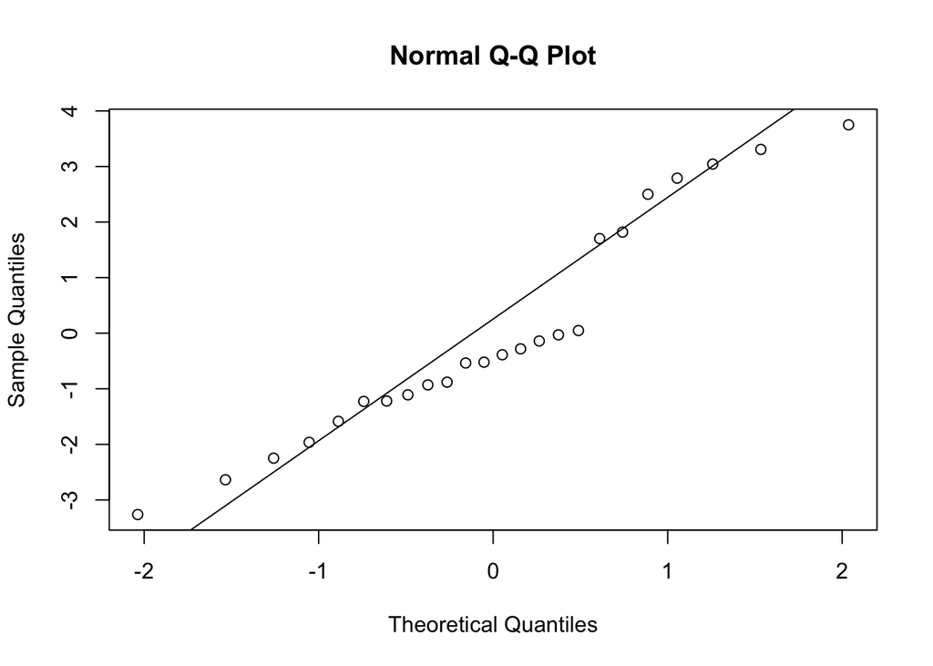

```r
# before log transform
qqnorm(resid(cells_trtY_models$x25_cd19_cd3_b_cells))
qqline(resid(cells_trtY_models$x25_cd19_cd3_b_cells))
```

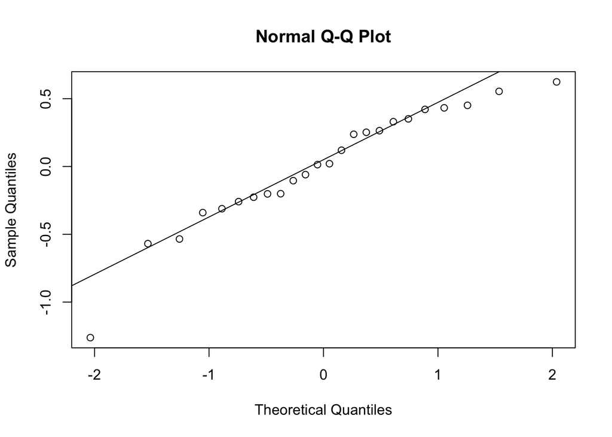

```r
# after log transform
qqnorm(resid(cells_log2_Y_models$x25_cd19_cd3_b_cells))
qqline(resid(cells_log2_Y_models$x25_cd19_cd3_b_cells))
```

## Red treatment

```r
# subset data into yellow results
cells_log2_R_long <- cells_log2_long %>%
  filter(intervention == "Red")
```

```r
# lmer model function
cells_log2_R_function <- function(cells_log2_R_long) {
  lmer(log2_cell_value ~ sequence + (1|patient_id), data = cells_log2_R_long, REML = TRUE)
}

# break data up into subsets based on cytokine, then apply funtion to each subset
cells_log2_R_models <- map(split(cells_log2_R_long,
                              cells_log2_R_long$cell_type),
                   cells_log2_R_function)

# create single data frame of results. apply tidy from broom.mixed package to clean up results
cells_log2_R_results <- map_df(cells_log2_R_models,
                            tidy,
                            .id = "cell_type")

cells_log2_R_results_coef <- cells_log2_R_results %>%
  filter(effect == "fixed") %>%
  filter(term != "(Intercept)") %>%
  add_significance(p.col = "p.value",
                   output.col = "p.sig",
                   cutpoints = c(0, 1e-04, 0.001, 0.01, 0.05, 1),
                   symbols = c("****", "***", "**", "*", "ns")
                   )
```

### Results

```r
kable(cells_log2_R_results_coef, format = "markdown", digits = 3)
```

| cell_type | effect | group | term | estimate | std.error | statistic | df | p.value | p.sig |
| --- | --- | --- | --- | --- | --- | --- | --- | --- | --- |
| x01_cd45_cd66b_lymph_dc_mono | fixed | NA | sequenceY_R | -0.049 | 0.032 | -1.539 | 10.00 | 0.155 | ns |
| x02_cd45_cd66b_grans | fixed | NA | sequenceY_R | 0.527 | 0.808 | 0.652 | 10.00 | 0.529 | ns |
| x03_cd3_cd45_cd3_t_cells | fixed | NA | sequenceY_R | 0.524 | 0.345 | 1.519 | 10.00 | 0.160 | ns |
| x04_tc_rgd_cd3_ab_t_cells | fixed | NA | sequenceY_R | 0.534 | 0.365 | 1.463 | 10.00 | 0.174 | ns |
| x05_cd4_cd8_cd8_t_cells | fixed | NA | sequenceY_R | 0.658 | 0.367 | 1.792 | 10.00 | 0.103 | ns |
| x06_cd45ro_cd45ra_naive_cd8 | fixed | NA | sequenceY_R | 1.315 | 0.788 | 1.670 | 10.00 | 0.126 | ns |
| x07_cd46ro_cd45ra_cm_cd8 | fixed | NA | sequenceY_R | 0.841 | 0.543 | 1.550 | 10.00 | 0.152 | ns |
| x08_cd45ro_cd45ra_em_cd8 | fixed | NA | sequenceY_R | 0.525 | 0.743 | 0.707 | 10.00 | 0.496 | ns |
| x09_cd45r0_cd45ra_te_cd8 | fixed | NA | sequenceY_R | -0.287 | 0.318 | -0.903 | 10.00 | 0.388 | ns |
| x10_cd38_hladr_activated_cd8 | fixed | NA | sequenceY_R | -0.229 | 0.346 | -0.662 | 10.00 | 0.523 | ns |
| x11_cd4_cd8_cd4_t_cells | fixed | NA | sequenceY_R | 0.558 | 0.527 | 1.058 | 10.00 | 0.315 | ns |
| x12_cd45ro_cd45ra_naive_cd4 | fixed | NA | sequenceY_R | 1.141 | 0.723 | 1.578 | 10.00 | 0.146 | ns |
| x13_cd45ro_cd45ra_cm_cd4 | fixed | NA | sequenceY_R | 0.458 | 0.533 | 0.860 | 10.00 | 0.410 | ns |
| x14_cd45ro_cd45ra | fixed | NA | sequenceY_R | 0.298 | 0.369 | 0.806 | 10.00 | 0.439 | ns |
| x15_cd45ro_cd45ra_te_cd4 | fixed | NA | sequenceY_R | 0.568 | 1.041 | 0.546 | 10.00 | 0.597 | ns |
| x16_cd38_hladr_activated_cd4 | fixed | NA | sequenceY_R | 0.078 | 0.376 | 0.207 | 10.00 | 0.840 | ns |
| x17_cd25_cd127_tregs | fixed | NA | sequenceY_R | 0.685 | 0.418 | 1.638 | 10.00 | 0.132 | ns |
| x18_ccr4_cd4_total_ccr4_treg | fixed | NA | sequenceY_R | 0.743 | 0.410 | 1.813 | 10.00 | 0.100 | ns |
| x19_cd45ra_cd45ro_ccr4_treg_naive | fixed | NA | sequenceY_R | 0.914 | 0.860 | 1.062 | 10.00 | 0.313 | ns |
| x20_hladr_total_ccr4_treg_activated | fixed | NA | sequenceY_R | 0.365 | 0.324 | 1.126 | 10.00 | 0.286 | ns |
| x21_cd45ra_cd45ro_ccr4_treg_memory | fixed | NA | sequenceY_R | 0.705 | 0.409 | 1.724 | 10.00 | 0.115 | ns |
| x22_cxcr3_ccr6_th1 | fixed | NA | sequenceY_R | 0.623 | 1.191 | 0.523 | 10.00 | 0.613 | ns |
| x23_cxcr3_ccr6_th2 | fixed | NA | sequenceY_R | 2.133 | 1.316 | 1.620 | 10.00 | 0.136 | ns |
| x24_cxcr3_ccr6_th17 | fixed | NA | sequenceY_R | 2.233 | 1.285 | 1.738 | 10.00 | 0.113 | ns |
| x25_cd19_cd3_b_cells | fixed | NA | sequenceY_R | -0.120 | 0.506 | -0.237 | 10.00 | 0.818 | ns |
| x26_cd27_ig_d_naive_b_cells | fixed | NA | sequenceY_R | 0.023 | 0.565 | 0.041 | 10.00 | 0.968 | ns |
| x27_cd27_ig_d_memory_b_cells | fixed | NA | sequenceY_R | -0.695 | 0.554 | -1.253 | 10.00 | 0.239 | ns |
| x28_cd27_ig_d_memory_resting_b_cells | fixed | NA | sequenceY_R | -0.759 | 0.741 | -1.025 | 10.00 | 0.330 | ns |
| x30_cd27_cd38_plasmablasts | fixed | NA | sequenceY_R | -0.797 | 0.531 | -1.503 | 8.25 | 0.170 | ns |
| x31_cd14_monocytes | fixed | NA | sequenceY_R | -0.974 | 0.465 | -2.096 | 10.00 | 0.063 | ns |
| x32_cd16_non_classical_mono | fixed | NA | sequenceY_R | -1.510 | 0.733 | -2.061 | 10.00 | 0.066 | ns |
| x33_cd16_classical_mono | fixed | NA | sequenceY_R | -0.922 | 0.458 | -2.013 | 10.00 | 0.072 | ns |
| x34_hladr_cd56 | fixed | NA | sequenceY_R | -0.851 | 0.459 | -1.854 | 10.00 | 0.093 | ns |
| x35_cd16_cd123_cd11c_p_dc | fixed | NA | sequenceY_R | -1.282 | 0.684 | -1.874 | 10.00 | 0.090 | ns |
| x36_cd16_cd123_cd11c_m_dc | fixed | NA | sequenceY_R | -0.813 | 0.463 | -1.757 | 10.00 | 0.110 | ns |
| x37_cd56_cd161_cd123_nk_cells | fixed | NA | sequenceY_R | -0.343 | 0.671 | -0.512 | 10.00 | 0.620 | ns |
| x38_cd16_nk_cells | fixed | NA | sequenceY_R | -0.028 | 0.629 | -0.044 | 10.00 | 0.965 | ns |
| x40_cd14_mdsc_mono | fixed | NA | sequenceY_R | -1.309 | 0.717 | -1.825 | 10.00 | 0.098 | ns |
| x41_cd66b_mdsc_grans | fixed | NA | sequenceY_R | -0.441 | 1.071 | -0.412 | 10.00 | 0.689 | ns |

```r
# extract statistically significant cytokines
cells_log2_R_psig <- cells_log2_R_results_coef %>%
  filter(cells_log2_R_results_coef$p.value < 0.05)

print(cells_log2_R_psig$cell_type)
```

```
## character(0)
```

Now there arent any significant cells for red after log transforming

### Resid check

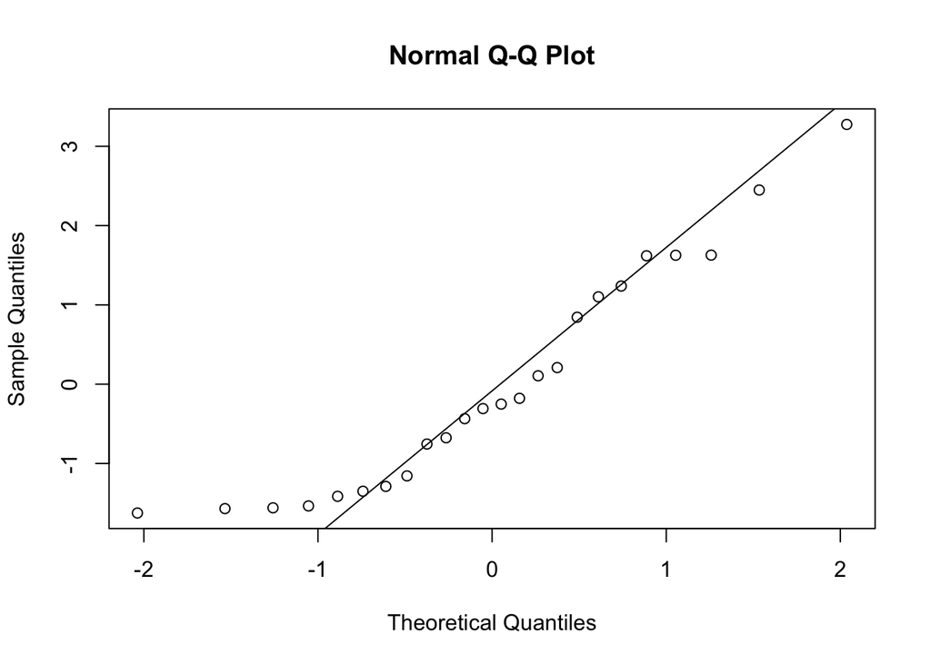

```r
# before log transform
qqnorm(resid(cells_trtR_models$x25_cd19_cd3_b_cells))
qqline(resid(cells_trtR_models$x25_cd19_cd3_b_cells))
```

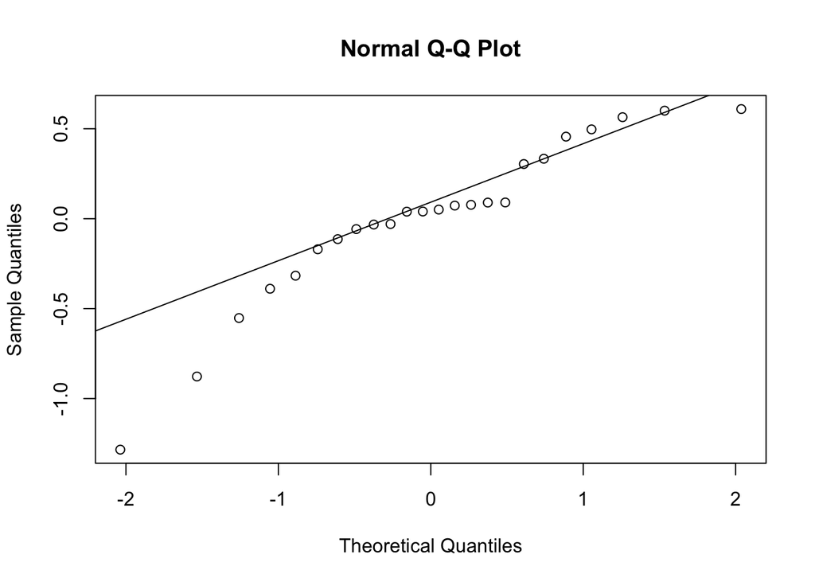

```r
# after log transform
qqnorm(resid(cells_log2_R_models$x25_cd19_cd3_b_cells))
qqline(resid(cells_log2_R_models$x25_cd19_cd3_b_cells))
```